# Your Digest for Wednesday, Sep 18, 2024 11:59 PM

[figure not shown]

- guidelines for antiplatelets in stroke

# Antiplatelets after ischemic stroke

- Dual antiplatelets 300+300 withing 24 hours is beneficial for TIA and Minor stroke. https://www.nejm.org/doi/full/10.1056/NEJMoa2309137
- **Dual antiplatelet therapy** is not recommended long term, and short term, dual antiplatelet therapy is recommended only in very specific patients, *including those with early arriving minor stroke* and *high-risk transient ischemic attack* or severe symptomatic intracranial stenosis. https://www.ahajournals.org/doi/10.1161/STR.0000000000000375
- early CT changes of ischemic stroke: https://youtu.be/3qugM8bh-RE?si=wOEqF6c2Skc1YGeh

# case discussion

How to evaluate cytopenia  
More specifically pancytopenia

Sensitivity and specificity of ANA  
Elisa and immunofluorescence

Use of c3 in diagnosis of SLE

What is the normal sequence of loss of functions in acute liver failure?  
Eg oedema -> bilirubinaemia -> coagulopathy? Or something else?  
How will the patient present

Do we load dual or single antiplatelets for stroke?

The **PLASMIC** score gives the probability of TTP based on clinical findings.

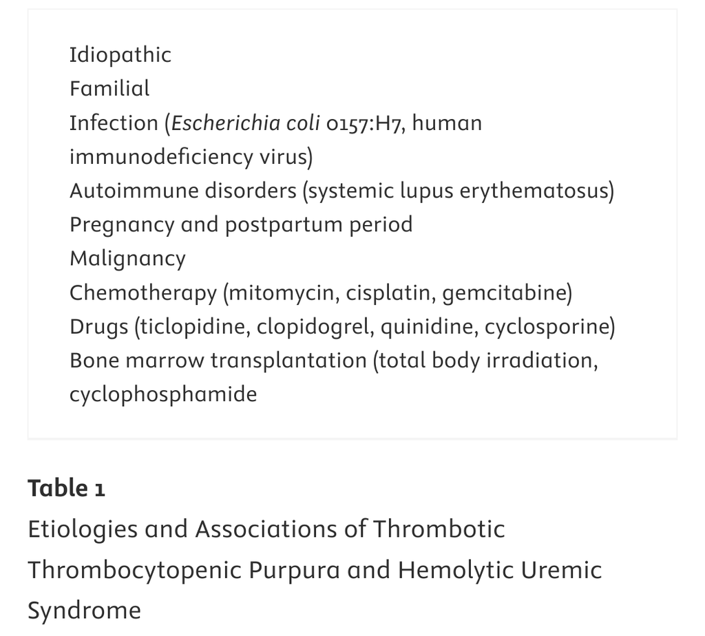

> [!INFO] When to use TPE  
> Therapeutic plasma exchange  
> The effectiveness of TPE for TMA syndromes other than TTP is uncertain. - UpToDate

[output not shown]